# R Notebook - Visualização de Dados com ggplot2 - Aula 2

# Visualização de Dados com ggplot2

O ggplot2 é baseado na ideia de **camadas gráficas**.

Cada gráfico é construído a partir de camadas, e essas camadas são essenciais para definir a aparência e a funcionalidade dos gráficos.

Agora iremos detalhar cada uma dessas camadas, abordando como elas podem ser usadas para criar visualizações poderosas e flexíveis no R.

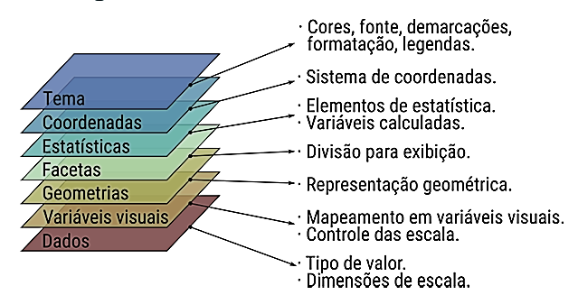

ggplot Camadas

## Criando as Bases de Dados

Primeiro, vamos recriar as bases de dados que utilizaremos nos exemplos.

```r
library(tidyverse)
library(gridExtra)
```

```r
# Tabela com informações de produtos
set.seed(123)
produtos <- tibble(
  produto_id = 101:150,
  nome_produto = paste("Produto", 101:150),
  categoria = sample(c("Alimentos", "Laticínios", "Bebidas", "Limpeza"), 50, replace = TRUE),
  preco = round(runif(50, 1, 20), 2)
)

produtos
```

| produto_id | nome_produto | categoria | preco |
| --- | --- | --- | --- |
| 101 | Produto 101 | Bebidas | 1.87 |
| 102 | Produto 102 | Bebidas | 9.40 |
| 103 | Produto 103 | Bebidas | 16.18 |
| 104 | Produto 104 | Laticínios | 3.32 |
| 105 | Produto 105 | Bebidas | 11.66 |
| 106 | Produto 106 | Laticínios | 4.92 |
| 107 | Produto 107 | Laticínios | 3.42 |
| 108 | Produto 108 | Laticínios | 15.31 |
| 109 | Produto 109 | Bebidas | 18.01 |
| 110 | Produto 110 | Alimentos | 8.11 |

[output cut: 40 more lines]

```r
# Tabela com informações de vendas
vendas <- tibble(
  venda_id = 1001:1050,
  produto_id = sample(101:150, 50, replace = TRUE),
  vendedor_id = sample(1:10, 50, replace = TRUE),
  quantidade = sample(1:20, 50, replace = TRUE),
  data_venda = as.Date("2024-07-01") + sample(0:30, 50, replace = TRUE)
)

vendas
```

| venda_id | produto_id | vendedor_id | quantidade | data_venda |
| --- | --- | --- | --- | --- |
| 1001 | 135 | 4 | 5 | 2024-07-31 |
| 1002 | 123 | 6 | 18 | 2024-07-14 |
| 1003 | 103 | 4 | 6 | 2024-07-14 |
| 1004 | 131 | 4 | 10 | 2024-07-06 |
| 1005 | 148 | 9 | 9 | 2024-07-18 |
| 1006 | 102 | 8 | 11 | 2024-07-02 |
| 1007 | 147 | 7 | 6 | 2024-07-24 |
| 1008 | 123 | 10 | 12 | 2024-07-08 |
| 1009 | 103 | 1 | 19 | 2024-07-11 |
| 1010 | 109 | 2 | 4 | 2024-07-21 |

[output cut: 40 more lines]

```r
# Introduzindo valores NA
vendas[sample(1:50, 5), "quantidade"] <- NA

# Tabela com informações de vendedores
vendedores <- tibble(
  vendedor_id = 1:10,
  nome_vendedor = c("Alice", "Bruno", "Carla", "David", "Eva", "Fernando", "Gisele", "Hugo", "Irene", "Jorge"),
  regiao = sample(c("Norte", "Sul", "Leste", "Oeste"), 10, replace = TRUE)
)

vendedores
```

| vendedor_id | nome_vendedor | regiao |
| --- | --- | --- |
| 1 | Alice | Oeste |
| 2 | Bruno | Sul |
| 3 | Carla | Norte |
| 4 | David | Sul |
| 5 | Eva | Leste |
| 6 | Fernando | Leste |
| 7 | Gisele | Leste |
| 8 | Hugo | Sul |
| 9 | Irene | Norte |
| 10 | Jorge | Sul |

## Camada 1: Dados

Quando falamos da camada de dados, estamos nos referindo ao **tipo de variável** com que estamos lidando:

- **Quantitativa**: variável numérica discreta ou contínua.
- **Qualitativa**: variável nominal ou ordinal.
- **Cronológica**: variáveis de data ou data-tempo.
- **Geográfica**: objetos como polígonos ou localizações.

Dependendo do tipo de variável, diferentes visualizações são mais adequadas. Isso nos ajuda a escolher como mapear as variáveis nos gráficos.

### Exemplo com variáveis quantitativas e qualitativas:

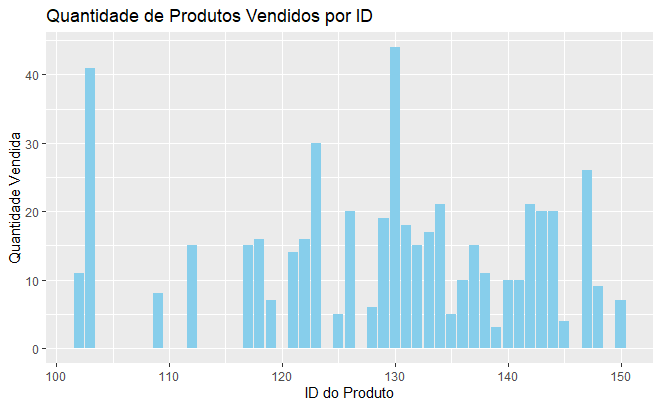

```r
# Gráfico básico mostrando a quantidade vendida por produto
ggplot(vendas, aes(x = produto_id, y = quantidade)) +
  geom_bar(stat = "identity", fill = "skyblue") +
  labs(title = "Quantidade de Produtos Vendidos por ID", x = "ID do Produto", y = "Quantidade Vendida")
```